# CSC321H5 Project 3.

## Question 3. Training

Now, we will write the functions required to train the model.

### Part (a) -- 10 pts

Write the function `train_model` that takes in (as parameters) the model, training data, validation data, and other hyperparameters like the batch size, weight decay, etc. This function should be somewhat similar to the training code that you wrote in Project 2, but with a major difference in the way we treat our training data.

Since our positive and negative training sets are separate, it is actually easier for us to generate separate minibatches of positive and negative training data! In each iteration, we'll take `batch_size / 2` positive samples and `batch_size / 2` negative samples. We will also generate labels of 1's for the positive samples, and 0's for the negative samples.

Here's what we will be looking for:

- main training loop; choice of loss function; choice of optimizer
- obtaining the positive and negative samples
- shuffling the positive and negative samples at the start of each epoch
- in each iteration, take `batch_size / 2` positive samples and `batch_size / 2` negative samples as our input for this batch
- in each iteration, take `np.ones(batch_size / 2)` as the labels for the positive samples, and `np.zeros(batch_size / 2)` as the labels for the negative samples
- conversion from numpy arrays to PyTorch tensors, making sure that the input has dimensions "NCHW", use the `.transpose()` method in either PyTorch or numpy
- computing the forward and backward passes
- after every epoch, checkpoint your model (Project 2 has in-depth instructions and examples for how to do this)
- after every epoch, report the accuracies for the training set and validation set
- track the training curve information and plot the training curve

```python
# Write your code here
def make_data(data):
    same = generate_same_pair(data)
    dif = generate_different_pair(data)
    out1 = []
    out2 = []
    for i in range(np.shape(same)[0]):
        out1.append(same[i, :, :, :])
    for i in range(np.shape(dif)[0]):
        out2.append(dif[i, :, :, :])
    return out1, out2

def get_batch(same, dif, start, end):
    xs = []
    for i in range(start//2, end//2):
        xs.append(same[i])
    for i in range(start//2, end//2):
        xs.append(dif[i])
    return xs, np.concatenate((np.ones((end-start)//2), np.zeros((end-start)//2)))

def train_model(model, t_data, v_data, batch_size=50, learning_rate=0.001, num_epochs=100, checkpoint_path='./ckpt-epoch{}.pk'):
    criterion = nn.CrossEntropyLoss()
    optimizer = optim.Adam(model.parameters(), lr=learning_rate)
    optimizer.zero_grad()

    iters, losses, train_acc, val_acc, iters_sub, t_pos, t_negs, v_pos, v_negs = [], [], [], [], [], [], [], [], []

    same, dif = make_data(t_data)

    n = 0
    start = time.time()
    last = start
    print("")
    for epoch in range(num_epochs):
        random.shuffle(same)
        random.shuffle(dif)
        for batch in range(0, np.shape(same)[0], batch_size):
            if (batch + batch_size) > np.shape(same)[0]:
                break
            xs, ts = get_batch(same, dif, batch, batch + batch_size)

            xs = torch.Tensor(xs)
            xs = xs.transpose(1, 3)
            ts = torch.Tensor(ts).long()

            zs = model(xs)
            loss = criterion(zs, ts)
            loss.backward()
            optimizer.step()
            optimizer.zero_grad()

            iters.append(n)
            losses.append(float(loss)/batch_size)

            # if n%1 == 0:
            n += 1

        iters_sub.append(epoch)
        train_cost = float(loss.detach().numpy())
        train_pos_acc, train_neg_acc = get_accuracy(model, t_data, batch_size)
        valid_pos_acc, valid_neg_acc = get_accuracy(model, v_data, batch_size)
        t_pos.append(train_pos_acc)
        t_negs.append(train_neg_acc)
        v_pos.append(valid_pos_acc)
        v_negs.append(valid_neg_acc)
        print("Iter %d. [Train Pos Acc %.0f%%, Train Neg Acc %.0f%%, Valid Pos Acc %.0f%%, Valid Neg Acc %.0f%%, Loss %f]" % (
              n, train_pos_acc * 100, train_neg_acc * 100, valid_pos_acc * 100, valid_neg_acc * 100, train_cost))
        now = time.time()
        print("last iteration: "+str(round(now-last, 5))+" seconds")
        print("elapsed time: "+str(round(now-start, 5))+" seconds\n")
        last = now


        if (checkpoint_path is not None):
            torch.save(model.state_dict(), checkpoint_path.format(n))



    return iters, losses, iters_sub, t_pos, t_negs, v_pos, v_negs

def plot_learning_curve(iters, losses, iters_sub, t_pos, t_negs, v_pos, v_negs):
    plt.title("Learning Curve: Loss per Iteration")
    plt.plot(iters, losses, label="Train")
    plt.xlabel("Iteration")
    plt.ylabel("loss")
    plt.show()

    plt.title("Learning Curve: Accuracy per Epoch")
    plt.plot(iters_sub, t_pos, label="Training Positive")
    plt.plot(iters_sub, t_negs, label="Training Negative")
    plt.plot(iters_sub, v_pos, label="Validation Positive")
    plt.plot(iters_sub, v_negs, label="Validation Negative")
    plt.xlabel("Epoch")
    plt.ylabel("Accuracy")
    plt.legend(loc='best')
    plt.show()
```

### Part (b) -- 2 pts

Sanity check your code from Q3(a) and from Q2(a) and Q2(b) by showing that your models can memorize a very small subset of the training set (e.g. 5 images). You should be able to achieve 90%+ accuracy relatively quickly (within ~30 or so iterations).

(If you have trouble with CNN() but not CNNChannel(), try reducing $n$, e.g. try working with the model `CNN(2)`)

```
Iter 1. [Train Pos Acc 100%, Train Neg Acc 0%, Valid Pos Acc 100%, Valid Neg Acc 0%, Loss 0.693051]
last iteration: 2.13539 seconds
elapsed time: 2.13539 seconds

Iter 2. [Train Pos Acc 0%, Train Neg Acc 100%, Valid Pos Acc 0%, Valid Neg Acc 100%, Loss 0.692960]
last iteration: 2.17033 seconds
elapsed time: 4.30572 seconds

Iter 3. [Train Pos Acc 0%, Train Neg Acc 100%, Valid Pos Acc 0%, Valid Neg Acc 100%, Loss 0.693251]
last iteration: 2.13687 seconds
elapsed time: 6.44259 seconds

Iter 4. [Train Pos Acc 0%, Train Neg Acc 100%, Valid Pos Acc 0%, Valid Neg Acc 100%, Loss 0.693574]
last iteration: 2.1046 seconds
elapsed time: 8.54719 seconds

Iter 5. [Train Pos Acc 0%, Train Neg Acc 100%, Valid Pos Acc 0%, Valid Neg Acc 100%, Loss 0.693917]
last iteration: 2.18444 seconds
elapsed time: 10.73163 seconds

Iter 6. [Train Pos Acc 0%, Train Neg Acc 100%, Valid Pos Acc 0%, Valid Neg Acc 100%, Loss 0.693470]
last iteration: 2.30609 seconds
elapsed time: 13.03772 seconds

Iter 7. [Train Pos Acc 0%, Train Neg Acc 100%, Valid Pos Acc 0%, Valid Neg Acc 100%, Loss 0.693524]
last iteration: 2.40067 seconds
elapsed time: 15.43839 seconds

Iter 8. [Train Pos Acc 0%, Train Neg Acc 100%, Valid Pos Acc 0%, Valid Neg Acc 100%, Loss 0.692632]
last iteration: 2.24154 seconds
elapsed time: 17.67992 seconds

Iter 9. [Train Pos Acc 0%, Train Neg Acc 100%, Valid Pos Acc 0%, Valid Neg Acc 100%, Loss 0.692293]
last iteration: 2.28666 seconds
elapsed time: 19.96658 seconds

Iter 10. [Train Pos Acc 0%, Train Neg Acc 100%, Valid Pos Acc 0%, Valid Neg Acc 100%, Loss 0.692491]
last iteration: 2.23634 seconds
elapsed time: 22.20292 seconds

```

[output cut: 184 more lines]

```
Iter 57. [Train Pos Acc 100%, Train Neg Acc 100%, Valid Pos Acc 92%, Valid Neg Acc 25%, Loss 0.000057]
last iteration: 2.33089 seconds
elapsed time: 145.8564 seconds

Iter 58. [Train Pos Acc 100%, Train Neg Acc 100%, Valid Pos Acc 92%, Valid Neg Acc 25%, Loss 0.000072]
last iteration: 2.11706 seconds
elapsed time: 147.97346 seconds

Iter 59. [Train Pos Acc 100%, Train Neg Acc 100%, Valid Pos Acc 92%, Valid Neg Acc 25%, Loss 0.000041]
last iteration: 2.14607 seconds
elapsed time: 150.11954 seconds

Iter 60. [Train Pos Acc 100%, Train Neg Acc 100%, Valid Pos Acc 92%, Valid Neg Acc 25%, Loss 0.000024]
last iteration: 2.08795 seconds
elapsed time: 152.20748 seconds
```

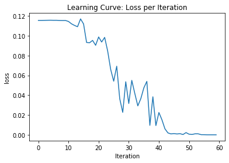

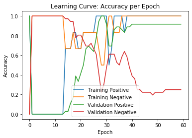

```python
# Write your code here. Remember to include your results so that your TA can
# see that your model attains a high training accuracy. (UPDATED March 12)
mod = CNNChannel(6)
learning_curve_info = train_model(mod, train_data[:2, :, :, :, :, :], valid_data, batch_size=6, num_epochs=60, checkpoint_path='./overfit/ckpt-overfit-epoch{}.pk') # look! it works!
plot_learning_curve(*learning_curve_info)
```